# Exploratory Factor Analysis (EFA)

Author

Riccardo Volpato

# Data Preparation

```r
options(readr.show_col_types = FALSE)
file_path <- "data/shared/TPSai+–+Prolific_EFA.csv"
raw_data  <- read_csv(file_path, n_max = 2)
colnames  <- names(raw_data)
q_text    <- setNames(sub(".* - ", "", as.character(raw_data[1, ])), colnames)
raw_data  <- read_csv(file_path, col_names = colnames, skip = 2)
```

```r
factors_map <- read_csv('surveys/efa_qs.csv')
cols_tpsai <- sprintf("TPSAI_%d", seq_along(seq_along(1:nrow(factors_map))))
```

```r
# check that survey and factors correspond
data.frame(
  survey_col  = cols_tpsai,
  survey_q    = unname(q_text[cols_tpsai]),
  factor_item = factors_map$Item
) %>%
  mutate(match = survey_q == factor_item) |>
  filter(!match)  %>% nrow() == 0
```

```
[1] TRUE
```

```r
likert_levels <- c(
  "Strongly disagree"          = 1,
  "Disagree"                   = 2,
  "Somewhat disagree"          = 3,
  "Neither agree nor disagree" = 4,
  "Somewhat agree"             = 5,
  "Agree"                      = 6,
  "Strongly agree"             = 7
)

efa_data <- raw_data |>
  mutate(across(all_of(cols_tpsai), ~ likert_levels[.x])) |>
  select(all_of(cols_tpsai))
```

```r
# Rename columns TPSAI_1 through TPSAI_9 to TPSAI_01 through TPSAI_09
names(efa_data) <- gsub("^TPSAI_(\\d)$", "TPSAI_0\\1", names(efa_data))
cols_tpsai <- gsub("^TPSAI_(\\d)$", "TPSAI_0\\1", cols_tpsai)
```

**Number of responses**

```r
nrow(raw_data)
```

```
[1] 300
```

**Frequencies of use of generative AI for psychological support**

```r
raw_data |>
  count(FREQ) |>
  mutate(pct = round(n / sum(n) * 100, 1)) |>
  arrange(desc(n)) |>
  kable(col.names = c("Frequency", "N", "%"))
```

| Frequency | N | % |
| --- | --- | --- |
| Never | 104 | 34.7 |
| Several times a week | 56 | 18.7 |
| About once a week to a few times a month | 54 | 18.0 |
| Daily or multiple times a day | 48 | 16.0 |
| About once a month | 38 | 12.7 |

```r
# frequency grouped in three categories
freq_groups <- c(
  "Never"                                    = "Never",
  "About once a month"                       = "Rarely",
  "About once a week to a few times a month" = "Rarely",
  "Several times a week"                     = "Often",
  "Daily or multiple times a day"            = "Often"
)

raw_data |>
  mutate(FREQ_group = factor(freq_groups[FREQ], levels = c("Never", "Rarely", "Often"))) |>
  count(FREQ_group) |>
  mutate(pct = round(n / sum(n) * 100, 1)) |>
  arrange(desc(n)) |>
  kable(col.names = c("Frequency", "N", "%"))
```

| Frequency | N | % |
| --- | --- | --- |
| Never | 104 | 34.7 |
| Often | 104 | 34.7 |
| Rarely | 92 | 30.7 |

# Exploratory Factor Analysis (EFA)

EFA identifies hidden structures in a set of items. The core idea: if items correlate, they’re probably measuring a common underlying thing — a latent factor. EFA finds the factors that can reproduce the observed correlations, retaining the solution that leaves the smallest residuals. Throughout our EFA, we use polychoric correlation matrix rather than the standard Pearson correlation matrix, as polychoric correlations are more appropriate for ordinal Likert data (Boateng et al. 2018).

```r
R <- polychoric(efa_data %>% select(all_of(cols_tpsai)))$rho
n_obs <- nrow(efa_data)
```

Our theoretical assumption is that TPSai items are primarily organised into a top-level structure with the two factors of *Trust* and *Distrust.* Thus, the first step in our EFA is it explore the data we collected in its entirely, confirming whether the top-level Trust/Distrust factor structure exists or whether an entirely different emergent structure exists at the top level.

## Factorability

First, we report the Kaiser-Meyer-Olkin (KMO) index which asks whether the correlations among items are sufficiently compact and patterned to yield reliable factors. We compute both the overall measure of sampling adequacy (MSA) and the minimum per-item MSA.

```r
kmo <- KMO(R)
kmo$MSA
```

```
[1] 0.9630892
```

If the overall MSA is below 0.8, we inspect per-item MSA and drop any items with MSA < 0.5, then recompute the overall MSA. If the overall MSA remains below 0.8 after dropping problematic items, we will collect additional data before proceeding.

```r
tibble(
  item = names(kmo$MSAi),
  msa  = round(kmo$MSAi, 3)
) |>
  arrange(msa) |>
  kable(col.names = c("Item", "MSA"))
```

| Item | MSA |
| --- | --- |
| TPSAI_26 | 0.800 |
| TPSAI_27 | 0.919 |
| TPSAI_28 | 0.922 |
| TPSAI_25 | 0.928 |
| TPSAI_31 | 0.936 |
| TPSAI_29 | 0.948 |
| TPSAI_30 | 0.952 |
| TPSAI_17 | 0.953 |
| TPSAI_09 | 0.955 |
| TPSAI_05 | 0.956 |
| TPSAI_14 | 0.956 |
| TPSAI_04 | 0.960 |
| TPSAI_24 | 0.960 |
| TPSAI_18 | 0.961 |
| TPSAI_15 | 0.962 |
| TPSAI_23 | 0.964 |
| TPSAI_02 | 0.965 |
| TPSAI_16 | 0.965 |
| TPSAI_21 | 0.966 |
| TPSAI_12 | 0.967 |
| TPSAI_07 | 0.969 |
| TPSAI_08 | 0.971 |
| TPSAI_22 | 0.971 |
| TPSAI_03 | 0.972 |
| TPSAI_19 | 0.974 |
| TPSAI_20 | 0.975 |
| TPSAI_01 | 0.977 |
| TPSAI_10 | 0.977 |
| TPSAI_13 | 0.978 |
| TPSAI_11 | 0.980 |
| TPSAI_06 | 0.981 |

## How Many Factors?

We use multiple criteria to estimate the number of factors at the top level, as no single method is universally reliable. We report parallel analysis, inspect the scree plot, the Velicer MAP test, and VSS complexity indices.

**Parallel analysis** compares each factor’s eigenvalue from the real data against the mean eigenvalue from randomly generated correlation matrices of the same dimensions. Eigenvalues measure how much shared variance a factor accounts for. A factor is retained if its eigenvalue exceeds the random baseline, meaning it captures more variance than would be expected by chance alone.

We also inspect the **scree plot** generated by parallel analysis for a clear elbow, the point at which the drop in eigenvalues between consecutive factors becomes substantially smaller, indicating that remaining factors contribute little additional explanatory power.

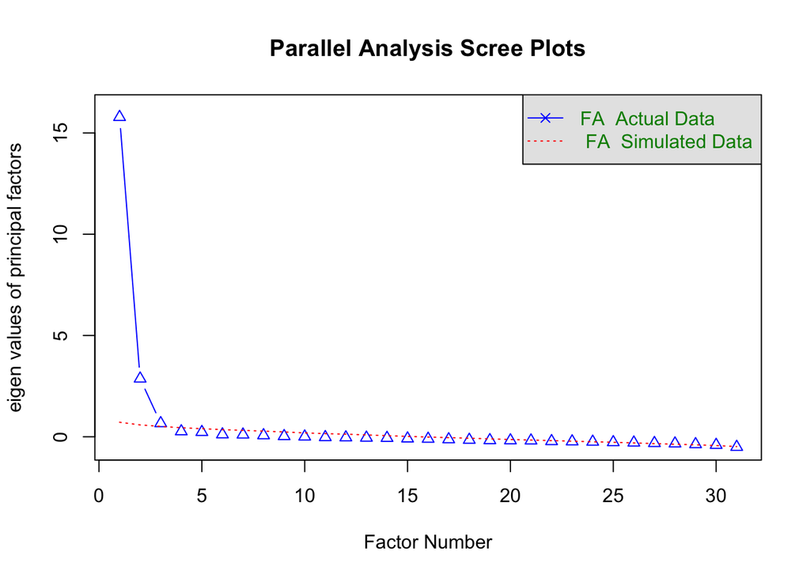

```
Parallel analysis suggests that the number of factors =  3  and the number of components =  NA
```

```r
pa <- fa.parallel(
  R,
  n.obs = nrow(efa_data),
  fm = "minres", # minimum residual: no distributional assumptions, suits ordinal data
  fa = "fa",     # factor analysis (not PCA)
)
```

```r
data.frame(
  Factor = 1:5,
  Actual = round(pa$fa.values[1:5], 2),
  Simulated = round(pa$fa.sim[1:5], 2)
) |> kable()
```

| Factor | Actual | Simulated |
| --- | --- | --- |
| 1 | 15.78 | 0.72 |
| 2 | 2.87 | 0.59 |
| 3 | 0.67 | 0.51 |
| 4 | 0.27 | 0.45 |
| 5 | 0.23 | 0.40 |

The **Velicer MAP test** iteratively partials out each factor from the correlation matrix and computes the average squared partial correlation. The optimal number of factors is the point at which this statistic is minimised, reflecting the solution where common variance is most fully extracted and only unique variance remains.

**Very Simple Structure (VSS)** evaluates how well a simplified factor solution, where each item loads on only one factor, reproduces the original correlation matrix. We report VSS complexity 1 and complexity 2 for completeness, but do not use them as primary decision criteria.

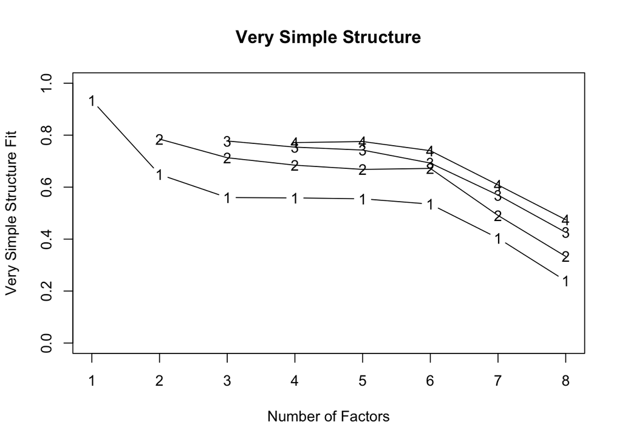

```
Very Simple Structure
Call: vss(x = R, rotate = "oblimin", fm = "minres", n.obs = nrow(efa_data))
VSS complexity 1 achieves a maximimum of 0.93  with  1  factors
VSS complexity 2 achieves a maximimum of 0.78  with  2  factors

The Velicer MAP achieves a minimum of 0.01  with  3  factors
BIC achieves a minimum of  -1317.36  with  3  factors
Sample Size adjusted BIC achieves a minimum of  -181.68  with  5  factors

Statistics by number of factors
  vss1 vss2   map dof chisq     prob sqresid  fit RMSEA   BIC SABIC complex
1 0.93 0.00 0.047 434  2398 2.1e-268      18 0.93 0.123   -77  1299     1.0
2 0.65 0.78 0.013 404  1106  1.3e-66      60 0.78 0.076 -1198    83     1.1
3 0.56 0.71 0.011 375   822  1.9e-35      63 0.78 0.063 -1317  -128     1.3
4 0.56 0.68 0.013 347   722  1.5e-28      64 0.77 0.060 -1257  -156     1.3
5 0.56 0.67 0.015 320   629  2.5e-22      64 0.77 0.057 -1197  -182     1.4
6 0.53 0.67 0.016 294   572  4.2e-20      73 0.74 0.056 -1105  -172     1.5
7 0.40 0.49 0.019 269   514  1.7e-17     101 0.64 0.055 -1021  -168     1.8
8 0.24 0.33 0.021 245   454  1.1e-14     133 0.53 0.053  -943  -167     2.2
  eChisq  SRMR eCRMS  eBIC
1   1512 0.074 0.076  -964
2    219 0.028 0.030 -2085
3    110 0.020 0.022 -2029
4     86 0.018 0.020 -1893
5     67 0.015 0.019 -1759
6     55 0.014 0.018 -1622
7     46 0.013 0.017 -1488
8     38 0.012 0.016 -1360
```

```r
vss(R, n.obs = nrow(efa_data), rotate = "oblimin", fm = "minres")
```

**Decision logic**

We use the MAP test and scree plot elbow as our primary criteria. If both agree, we adopt that solution. If they disagree, we examine VSS complexity 2 as additional evidence. If no clear convergence emerges across three criteria, we would consider all criteria (MAP, scree, VSS 1 & 2, parallel analysis) as well possibly inspect the factor solutions for different number of factors and make a choice and justify based on the cumulated evidence.

```r
# Set number of factors based on MAP and scree plot
n_factors <- 3  # replace with chosen number after inspecting criteria
```

Based on this, we arrive at a suggested number of factors and proceed as follows:

- **n = 1**: suggests a unidimensional structure without clear separation between Trust and Distrust. We do not proceed with the Trust/Distrust model.
- **n = 2**: suggests overlap with the Trust/Distrust model. We proceed to the EFA solution.
- **n > 2**: suggests an entirely new factor structure. We proceed to the EFA solution and investigate the emergent structure.

## EFA Solution

We extract the suggested number of factors using **MINRES** (minimum residual) estimation with **oblimin** rotation. MINRES makes no distributional assumptions about the data, making it appropriate for ordinal Likert items. Oblimin is an oblique rotation method that allows factors to correlate — a realistic assumption for psychological constructs such as Trust and Distrust, which are unlikely to be fully independent. Oblimin also simplifies the loading structure, making factors easier to interpret.

```r
efa <- fa(
  r = R,
  nfactors = n_factors,  # determined in previous section
  n.obs = nrow(efa_data),
  fm = "minres",          # minimum residual: no distributional assumptions
  rotate = "oblimin"      # oblique rotation: allows factors to correlate
)
```

We visualise the factor loadings as a heatmap, where each cell represents the strength and direction of the relationship between an item and a factor. Loadings close to 1 or -1 indicate a strong relationship; loadings close to 0 indicate little relationship. Bold values indicate the highest loading for that item across all factors.

```r
plot_loadings <- function(loadings, by_factor = FALSE) {
  loads <- loadings |>
    unclass() |>
    as.data.frame() |>
    rownames_to_column("item") |>
    pivot_longer(
      cols      = -item,
      names_to  = "factor",
      values_to = "loading"
    ) |>
    group_by(item) |>
    mutate(
      bold     = abs(loading) == max(abs(loading)),
      dom_fac  = factor[which.max(abs(loading))],   # which factor it loads on most
      dom_load = loading[which.max(abs(loading))],
      label    = as.character(round(loading, 2))
    ) |>
    ungroup()

  if (by_factor) {
    item_order <- loads |>
      distinct(item, dom_fac, dom_load) |>
      arrange(dom_fac, desc(abs(dom_load))) |>     # group by factor, then by strength
      pull(item)
    loads <- mutate(loads, item = factor(item, levels = item_order))
  } else {
    loads <- mutate(loads, item = factor(item))    # original alphabetical behaviour
  }

  ggplot(loads, aes(x = factor, y = item, fill = loading)) +
    geom_tile() +
    geom_text(data = filter(loads, !bold),
              aes(label = label, colour = abs(loading) > 0.5)) +
    geom_text(data = filter(loads, bold),
              aes(label = label, colour = abs(loading) > 0.5),
              fontface = "bold") +
    scale_colour_manual(values = c("TRUE" = "white", "FALSE" = "black"), guide = "none") +
    scale_fill_gradient2(low = "blue", mid = "white", high = "red",
                         midpoint = 0, limits = c(-1, 1),
                         oob = scales::squish) +
    scale_y_discrete(limits = rev) +
    theme_minimal(base_size = 14) +
    theme(legend.position = "right") +
    labs(x = "", y = "", fill = "")
}
```

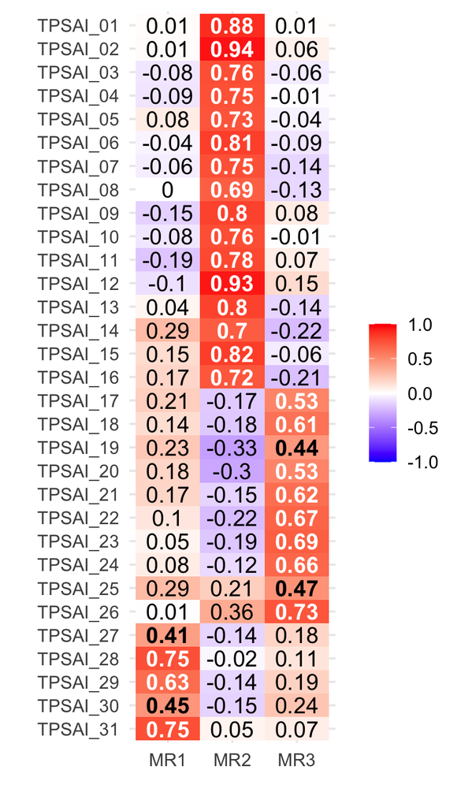

```r
plot_loadings(efa$loadings)
```

To interpret the factor structure, we examine which items load most strongly on each factor. Where the structure is emergent, we use item content to identify the underlying construct each factor represents.

Where the factor structure maps onto a theoretical model, either the Trust/Distrust (n = 2) or the 4F/8F models (n > 2), we additionally check whether items load on the correct theoretical factor. Items loading primarily on the wrong factor are candidates for removal or reversal:

- **Removal**: if the item’s content is not theoretically consistent with the factor it loads on
- **Reversal**: if the item’s content is theoretically consistent with the factor it loads on, but the loading is negative

We inspect the loading pattern for simple structure — ideally each item loads strongly on one factor and weakly on all others (Buchanan et al. 2014). We flag items for removal based on two empirical criteria:

- **Low primary loading**: primary loading < 0.4 — the item does not relate strongly enough to any factor
- **Cross-loading**: gap between primary and secondary loading < 0.05 — the item does not discriminate sufficiently between factors. We use a lenient threshold of 0.05 rather than the conventional 0.10, acknowledging that Trust and Distrust are genuinely correlated constructs and some cross-loading is expected.

Both criteria are applied independently — an item is flagged if it fails either criterion. Items near the thresholds are subject to theoretical review and may be retained if their content is theoretically justified.

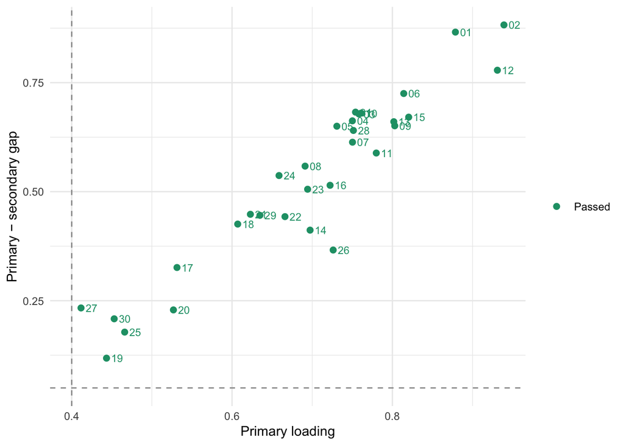

```r
min_primary <- 0.4
min_diff    <- 0.05

loadings_df <- efa$loadings |>
  unclass() |>
  as.data.frame() |>
  rownames_to_column("item") |>
  rowwise() |>
  mutate(
    abs_loads = list(sort(abs(c_across(-item)), decreasing = TRUE)),
    primary   = abs_loads[[1]],
    secondary = abs_loads[[2]],
    diff      = primary - secondary,
    flagged   = primary < min_primary | diff < min_diff
  ) |>
  ungroup()

ggplot(loadings_df, aes(primary, diff, colour = flagged)) +
  geom_vline(xintercept = min_primary, linetype = "dashed", colour = "grey60") +
  geom_hline(yintercept = min_diff,   linetype = "dashed", colour = "grey60") +
  geom_point(size = 2) +
  geom_text(aes(label = str_remove(item, "TPSAI_")),
            size = 3, hjust = -0.4, vjust = 0.5, show.legend = FALSE) +
  scale_colour_manual(values = c(`FALSE` = "#1D9E75", `TRUE` = "#D85A30"),
                      labels = c("Passed", "Flagged")) +
  labs(x = "Primary loading", y = "Primary − secondary gap", colour = NULL) +
  theme_minimal()
```

Items falling below the vertical dashed line have a low primary loading; items falling below the horizontal dashed line are cross-loaders. Items in the lower-left quadrant fail both criteria. Items not flagged by any criterion are retained. Items flagged by one or more criteria are candidates for removal, subject to theoretical review.

# Substructures

We apply this separately to Trust and Distrust items, using the theoretical item assignments to define each block. After item reduction, `cols_tpsai` contains only surviving items, so the blocks are defined as:

```r
trust_items    <- cols_tpsai[cols_tpsai %in% sprintf("TPSAI_%02d", 1:16)]
distrust_items <- cols_tpsai[cols_tpsai %in% sprintf("TPSAI_%02d", 17:31)]

R_trust    <- R[trust_items, trust_items]
R_distrust <- R[distrust_items, distrust_items]
```

We fit bifactor models with k = 2, 3, and 4 group factors for each block, covering the range between our 4F theoretical model (2 subgroups per factor) and our 8F theoretical model (4 subgroups per factor). The maximum k tested is additionally constrained by block size. We do not test values of k where floor(n_items / 3) < k, as this would make the minimum items per factor criterion unachievable by design.

A solution is acceptable only if **all** minimum requirements are met:

- **RMSEA < 0.10** — acceptable model fit
- **Minimum 3 items per group factor** — each group factor must be sufficiently represented
- **Max/min items ratio ≤ 3** — group factors must be reasonably balanced in size
- **ω_h < 0.90** — the general factor must not dominate to the point where group factors are trivial
- **≤ 20% of items are cross-loaders** — where a cross-loader is defined as an item whose gap between primary and secondary group factor loading is < 0.05

Where multiple solutions meet all minimum requirements, we prefer the solution with the fewest cross-loaders. Where cross-loaders are equal, we prefer the solution with the best factor balance (lowest ratio). Where both are equal, we prefer the solution with the lower BIC. If criteria point in different directions and no clear winner emerges, we report both solutions and discuss the trade-offs.

```r
compare_omega <- function(omega_list, labels = c("k=2", "k=3", "k=4"),
                          gap_threshold = 0.05, min_loading = 0.0) {

  map_dfr(seq_along(omega_list), function(i) {
    om  <- omega_list[[i]]
    sl  <- om$schmid$sl

    # Extract group factor columns only (exclude g, h2, u2, p2)
    group_cols <- sl[, grepl("^F", colnames(sl)), drop = FALSE]

    # Assign items to primary factor only if loading >= min_loading
    primary_factor <- apply(group_cols, 1, function(x) {
      if (max(abs(x)) < min_loading) return(NA)
      which.max(abs(x))
    })

    items_per_factor <- table(primary_factor[!is.na(primary_factor)])

    # Cross-loaders: gap between primary and secondary group factor loading < gap_threshold
    cross_loaders <- sum(apply(group_cols, 1, function(x) {
      sorted <- sort(abs(x), decreasing = TRUE)
      if (length(sorted) < 2) return(FALSE)
      (sorted[1] - sorted[2]) < gap_threshold
    }))

    n_items <- nrow(group_cols)

    tibble(
      model         = labels[[i]],
      RMSEA         = round(om$schmid$RMSEA["RMSEA"], 3),
      BIC           = round(om$schmid$BIC, 1),
      omega_h       = round(om$omega_h, 3),
      min_items     = min(items_per_factor),
      max_items     = max(items_per_factor),
      ratio         = round(max(items_per_factor) / min(items_per_factor), 1),
      cross_loaders = cross_loaders,
      cross_pct     = round(cross_loaders / n_items * 100, 1)
    )
  })
}
```

## Trust

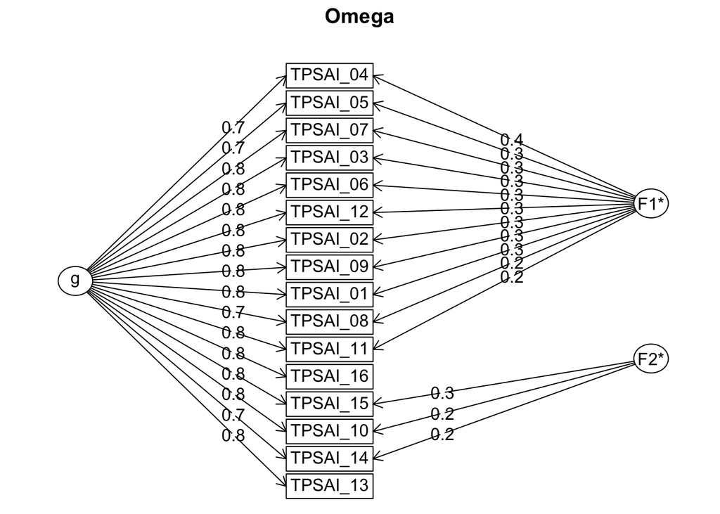

```r
omega_trust_2 <- omega(
  m        = R_trust,
  nfactors = 2,
  n.obs    = nrow(efa_data),
  fm       = "minres",
  rotate   = "oblimin"
)
```

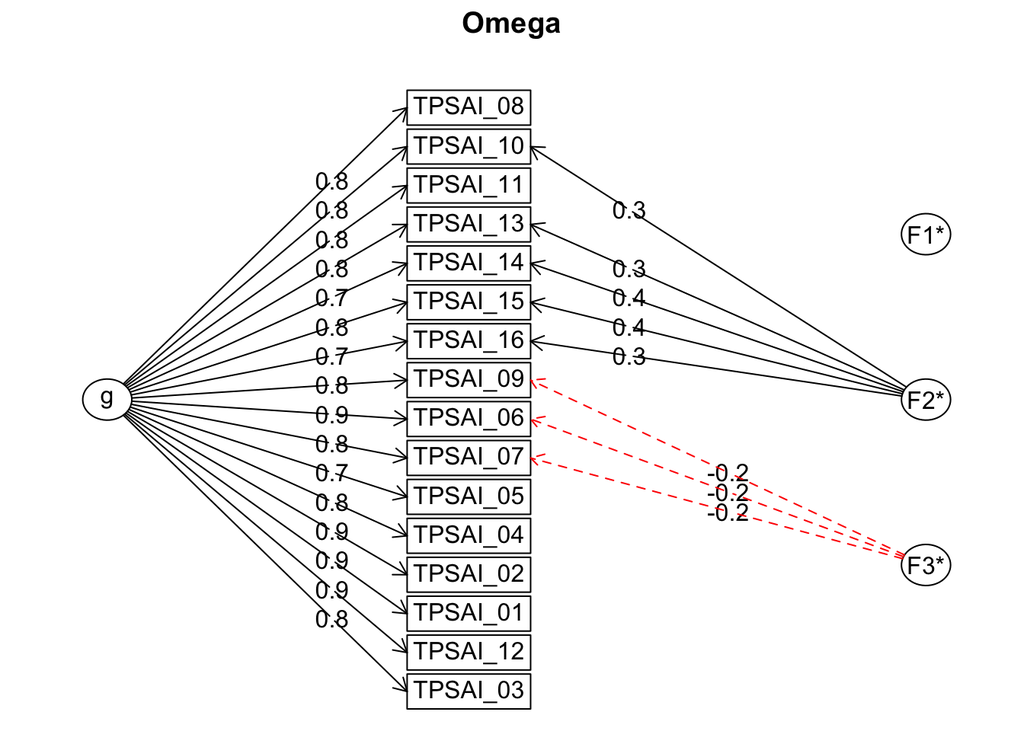

```r
omega_trust_3 <- omega(
  m        = R_trust,
  nfactors = 3,
  n.obs    = nrow(efa_data),
  fm       = "minres",
  rotate   = "oblimin"
)
```

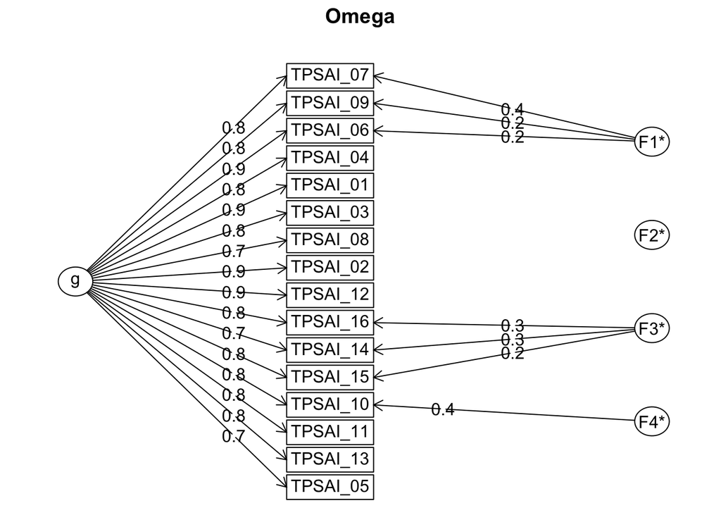

```r
omega_trust_4 <- omega(
  m        = R_trust,
  nfactors = 4,
  n.obs    = nrow(efa_data),
  fm       = "minres",
  rotate   = "oblimin"
)
```

```r
compare_omega(list(omega_trust_2, omega_trust_3, omega_trust_4)) |> kable()
```

| model | RMSEA | BIC | omega_h | min_items | max_items | ratio | cross_loaders | cross_pct |
| --- | --- | --- | --- | --- | --- | --- | --- | --- |
| k=2 | 0.067 | -297.4 | 0.875 | 4 | 12 | 3.0 | 2 | 12.5 |
| k=3 | 0.059 | -273.0 | 0.940 | 7 | 9 | 1.3 | 5 | 31.2 |
| k=4 | 0.057 | -230.1 | 0.941 | 2 | 7 | 3.5 | 6 | 37.5 |

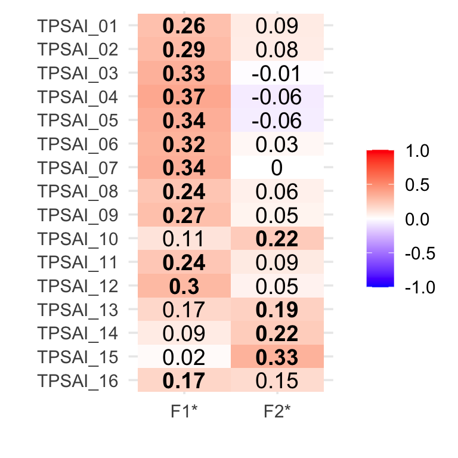

```r
sl_subset <- omega_trust_2$schmid$sl[, c("F1*", "F2*")]
plot_loadings(sl_subset)
```

## Distrust

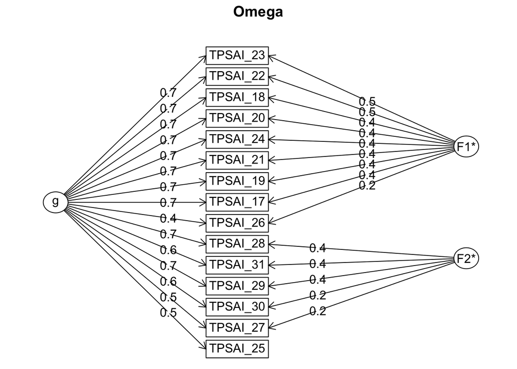

```r
omega_distrust_2 <- omega(
  m        = R_distrust,
  nfactors = 2,
  n.obs    = nrow(efa_data),
  fm       = "minres",
  rotate   = "oblimin"
)
```

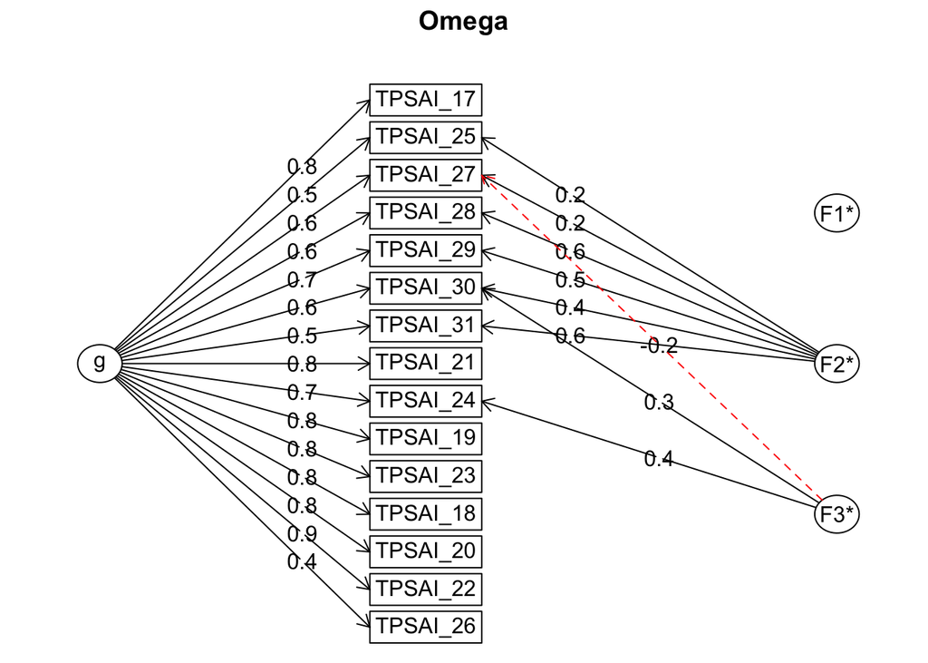

```r
omega_distrust_3 <- omega(
  m        = R_distrust,
  nfactors = 3,
  n.obs    = nrow(efa_data),
  fm       = "minres",
  rotate   = "oblimin"
)
```

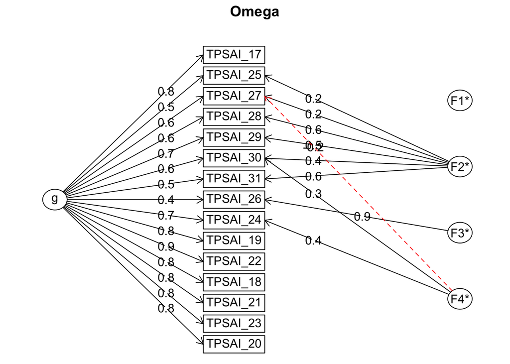

```r
omega_distrust_4 <- omega(
  m        = R_distrust,
  nfactors = 4,
  n.obs    = nrow(efa_data),
  fm       = "minres",
  rotate   = "oblimin"
)
```

```r
compare_omega(list(omega_distrust_2, omega_distrust_3, omega_distrust_4)) |> kable()
```

| model | RMSEA | BIC | omega_h | min_items | max_items | ratio | cross_loaders | cross_pct |
| --- | --- | --- | --- | --- | --- | --- | --- | --- |
| k=2 | 0.073 | -235.9 | 0.772 | 6 | 9 | 1.5 | 1 | 6.7 |
| k=3 | 0.061 | -224.9 | 0.877 | 7 | 8 | 1.1 | 5 | 33.3 |
| k=4 | 0.062 | -180.9 | 0.872 | 1 | 7 | 7.0 | 5 | 33.3 |

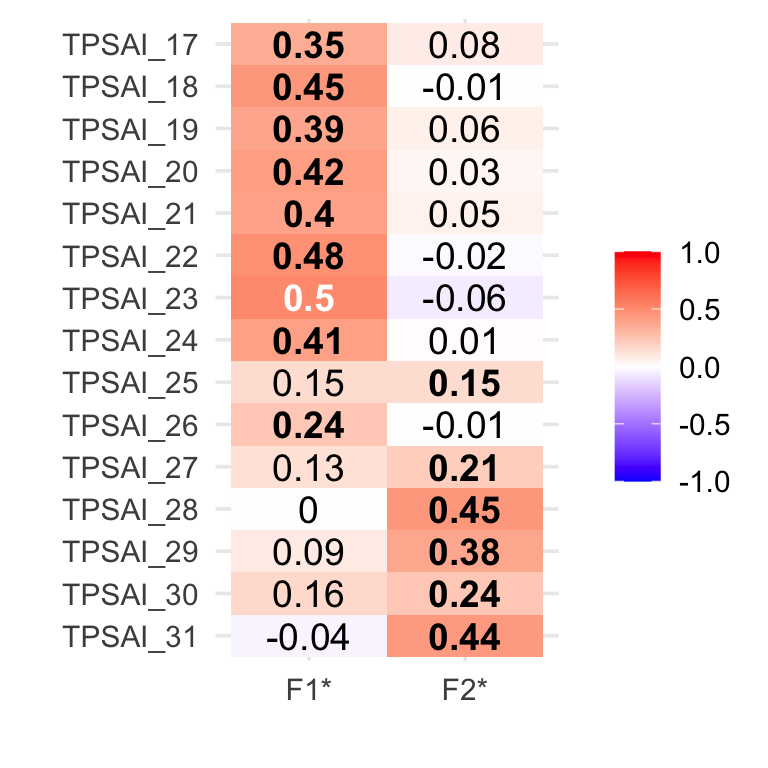

```r
sl_subset <- omega_distrust_2$schmid$sl[, c("F1*", "F2*")]
plot_loadings(sl_subset)
```

## References

Boateng, Godfred O., Torsten B. Neilands, Edward A. Frongillo, Hugo R. Melgar-Quiñonez, and Sera L. Young. 2018. “Best Practices for Developing and Validating Scales for Health, Social, and Behavioral Research: A Primer.” *Frontiers in Public Health* 6 (June). https://doi.org/10.3389/fpubh.2018.00149.

Buchanan, Erin M., Kathrene D. Valentine, and Stefan E. Schulenberg. 2014. “Exploratory and Confirmatory Factor Analysis: Developing the Purpose in Life Testshort Form.” *SAGE Research Methods Cases*, ahead of print, January 1. https://doi.org/10.1007/S10902-008-9124-3.